# Estudis d'Informàtica, Multimedia i Telecomunicacions

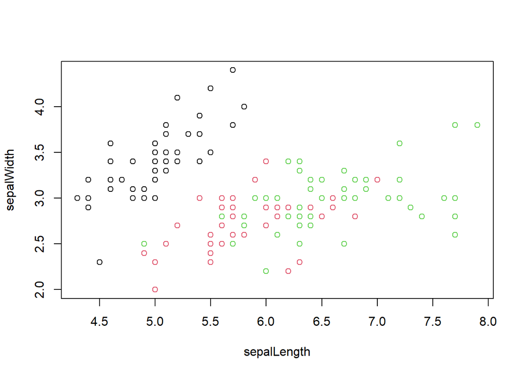

```r
plot(x[c(1,2)], col=as.factor(iris_data$class))
```

Podem observar que el sèpal no és un bon indicador per a diferenciar a les tres subespècies, no amb la metodologia kmeans, donat que dos de les subespecies estan massa mesclades per a poder diferenciar res.

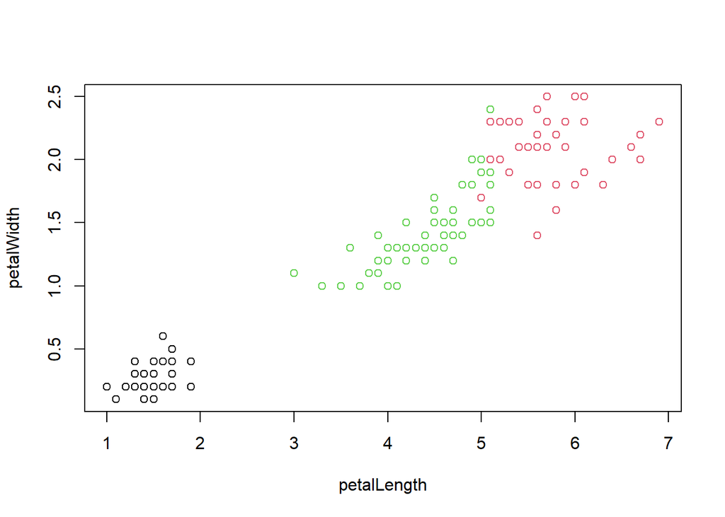

```r
# petalLength i petalWidth
plot(x[c(3,4)], col=iris3clusters$cluster)
```

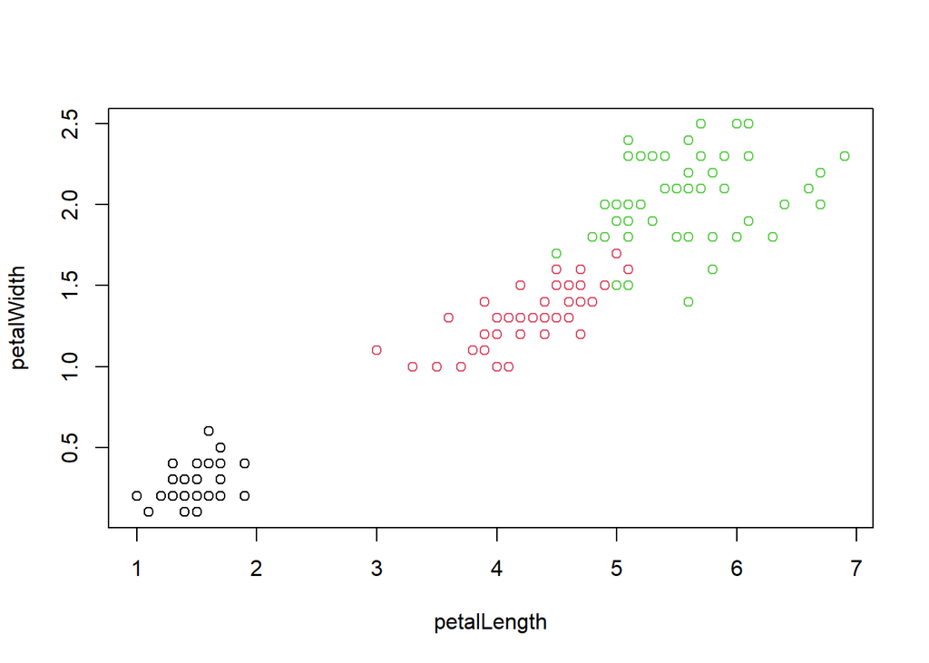

```r
plot(x[c(3,4)], col=as.factor(iris_data$class))
```

Per un altre banda, la mida del pètal sembla fer una millor feina per a dividir els tres tipus de flors. El grup format pels punts negres, que ha trobat l’algoritme, coincideix amb els de la flor Iris Setosa. Els altres dos grups,però s’entremesclen més, i hi ha alguns punts que es classifiquen com a Versicolor quan en realitat són Virginica.

Això ens ajuda a entendre com estan formats els grups i a referir-nos a ells en anàlisis posteriors.

Una última cosa que ens queda per fer, és sapiguer quines de les mostres inicials han estat mal classificades i com. Això ho aconseguirem amb la següent comanda.

```r
table(iris3clusters$cluster,iris_data$class)
```

```
##
##     Iris-setosa Iris-versicolor Iris-virginica
##   1          49               0              0
##   2           0               2             36
##   3           0              48             14
```

Ens permet així treure un percentatge de la precisió del model

```r
100*(36 + 48 + 49)/(133+(2+14))
```

```
## [1] 89.26174
```

## 3.2 Exercici 1.1

Prenent com a punt de partida els exemples, realitza un estudi similar amb un altra conjunt de dades. Poden ser dades reals del vostre àmbit laboral o d’algú repositori de dades d’Internet. Mireu per exemple: http://www.ics.uci.edu/~mlearn/MLSummary.html.

A l’hora de escollir la base de dades tingues en compte que ha de ser apropiada per a problemes no supervisats i que els atributs siguin també apropiats per al seu ús amb el kmeans.

No us oblideu de la fase de preparació i anàlisi de dades.

### 3.2.1 Resposta 1.1:

He seleccionat la base de dades de llavors que es troba a http://archive.ics.uci.edu/ml/datasets/seeds. Aquesta base de dades té els següents camps: 1. Area 2. Perimeter 3. Compactness C = 4*pi*A/P^2 4. length of kernel 5. width of kernel 6. asymmetry coefficien 7. length of kernel groove 8. class

Per sort, aquesta base de dades ja ha estat netejada majorment, però té parts en que el separador de valors es troba duplicat, com veiem a la línea 8, per exemple:

```r
linees <- readLines("http://archive.ics.uci.edu/ml/machine-learning-databases/00236/seeds_dataset.txt")
linees[8]
```

```
## [1] "14.11\t14.1\t0.8911\t5.42\t3.302\t2.7\t\t5\t\t1"
```

Anem a netejar-ho:

```r
linees <- gsub("\t\t", "\t", linees)
linees[8]
```

```
## [1] "14.11\t14.1\t0.8911\t5.42\t3.302\t2.7\t5\t1"
```

Ara ja podem convertir-ho a base de dades i veure un resum de les dades:

```r
seedData <- read.table(text=linees, sep="\t", header=FALSE)
colnames(seedData) <- c("area", "perimeter", "compactness", "kernel_lenght", "kernel_width", "asymmetry", "kernel_grove_length", "class")
summary(seedData)
```

```
##       area         perimeter      compactness     kernel_lenght
##  Min.   :10.59   Min.   :12.41   Min.   :0.8081   Min.   :4.899
##  1st Qu.:12.27   1st Qu.:13.45   1st Qu.:0.8569   1st Qu.:5.262
##  Median :14.36   Median :14.32   Median :0.8734   Median :5.524
##  Mean   :14.85   Mean   :14.56   Mean   :0.8710   Mean   :5.629
##  3rd Qu.:17.30   3rd Qu.:15.71   3rd Qu.:0.8878   3rd Qu.:5.980
##  Max.   :21.18   Max.   :17.25   Max.   :0.9183   Max.   :6.675
##   kernel_width     asymmetry      kernel_grove_length     class
##  Min.   :2.630   Min.   :0.7651   Min.   :4.519       Min.   :1
##  1st Qu.:2.944   1st Qu.:2.5615   1st Qu.:5.045       1st Qu.:1
##  Median :3.237   Median :3.5990   Median :5.223       Median :2
##  Mean   :3.259   Mean   :3.7002   Mean   :5.408       Mean   :2
##  3rd Qu.:3.562   3rd Qu.:4.7687   3rd Qu.:5.877       3rd Qu.:3
##  Max.   :4.033   Max.   :8.4560   Max.   :6.550       Max.   :3
```

Com en l’exemple, per tal de trobar les agrupacions “a cegues”, ignorem els valors de classe i fem servir només les 7 variables:

```r
seeds <- seedData[,1:7]
```

Aprofitant el mètode daisy de la llibreria cluster, com inicialment no coneixem el número òptim de clústers, provem amb varis valors. Aprofitem el mateix codi de l’exemple, canviant les variables per tal d’evitar possibles problemes

```r
daisy_seeds <- daisy(seeds)
resultats <- rep(0, 10)
for (i in c(2,3,4,5,6,7,8,9,10))
{
  encaix        <- kmeans(seeds, i)
  cluster_y     <- encaix$cluster
  siluetes      <- silhouette(cluster_y, daisy_seeds)
  resultats[i]  <- mean(siluetes[,3])
}
```

Seguint altra vegada els passos de l’exemple, mostrem en una gràfica els valors de la silueta mitja de cada prova per comprovar quin número de clústers és el millor

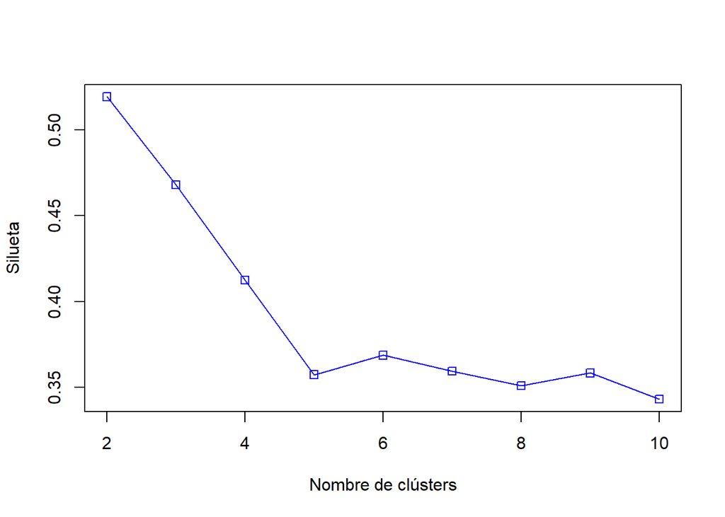

```r
plot(2:10,resultats[2:10],type="o",col="blue",pch=0,xlab="Nombre de clústers",ylab="Silueta")
```

Altra vegada veiem que el millor valor de clústers sembla ser 2 (sol ser normal, com menys grups més fàcil és d’obtenir grups diferents). De totes maneres, el que ens interessa és tenir com més grups millor mantenint un model prou bo.

Seguint amb l’exemple, anem a veure quin és el millor model segons el mètode elbow.

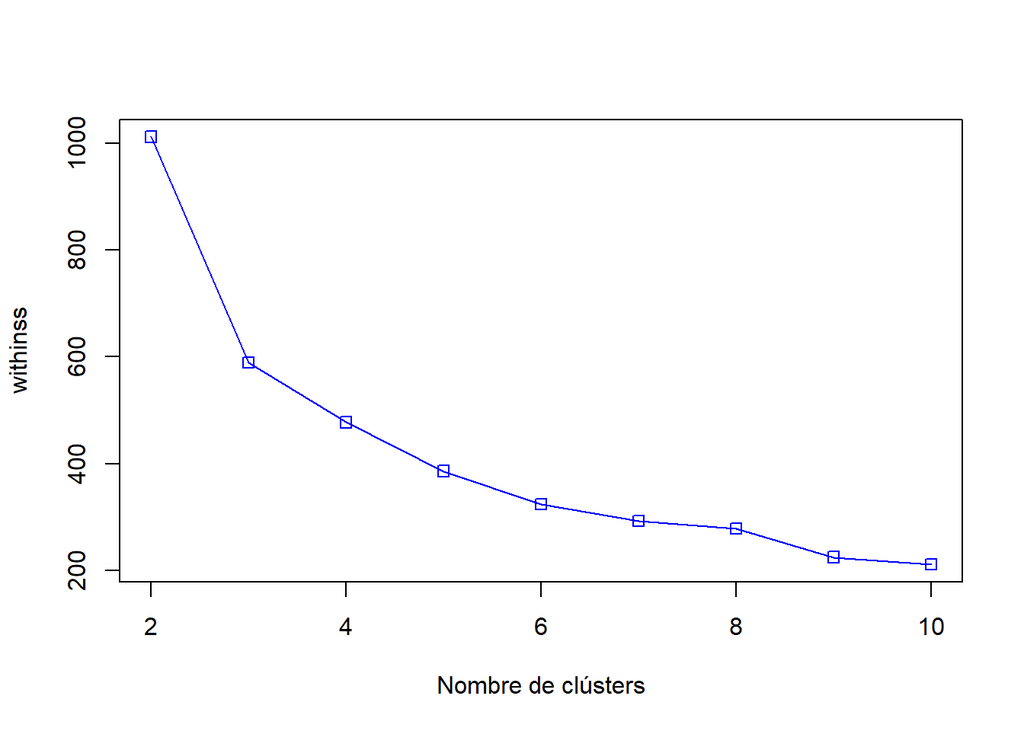

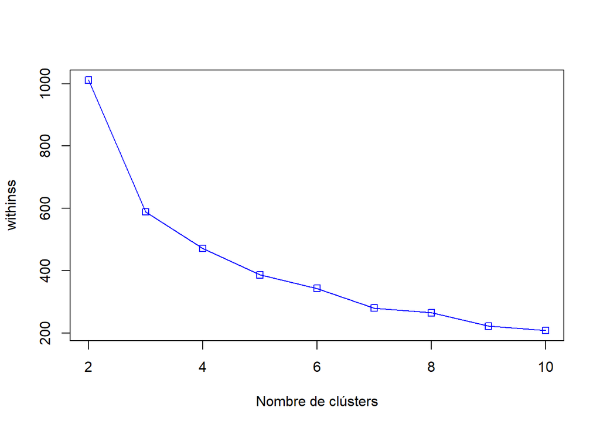

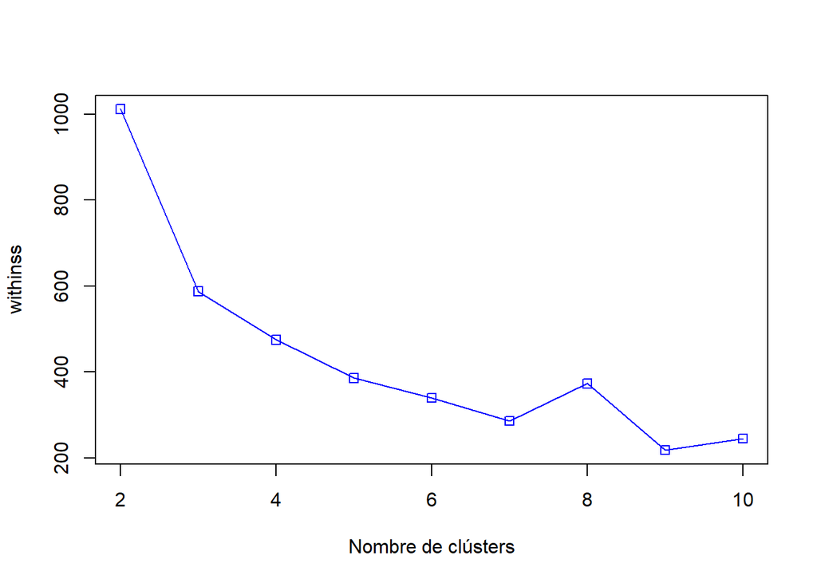

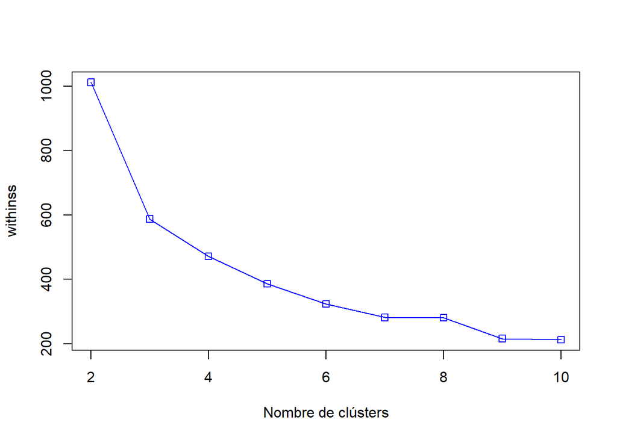

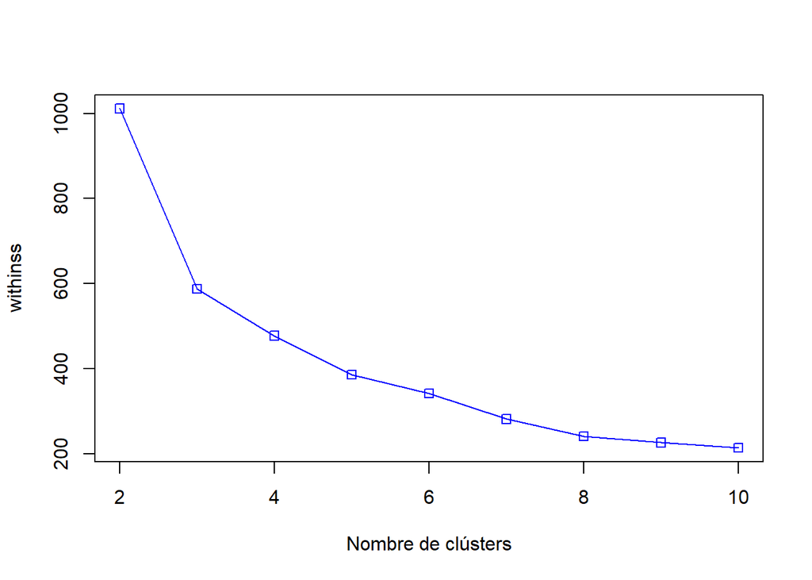

```r
resultats <- rep(0, 10)
for(j in c(1,2,3,4,5))
{
    for (i in c(2,3,4,5,6,7,8,9,10))
    {
        encaix        <- kmeans(seeds, i)
        resultats[i]  <- encaix$tot.withinss
    }
    plot(2:10,resultats[2:10],type="o",col="blue",pch=0,xlab="Nombre de clústers",ylab="withinss")
    j=j+1
    Sys.sleep(0.5)
}
```

Fent servir la funció kmeansruns del paquet fpc (que ja s’ha cridat anteriorment), veiem els criteris de silueta mitja (asw) i Calinski-Harabasz (“ch”).

```r
encaix_ch  <- kmeansruns(seeds, krange = 1:10, criterion = "ch")
encaix_asw <- kmeansruns(seeds, krange = 1:10, criterion = "asw")

encaix_ch$bestk
```

```
## [1] 3
```

```r
encaix_asw$bestk
```

```
## [1] 2
```

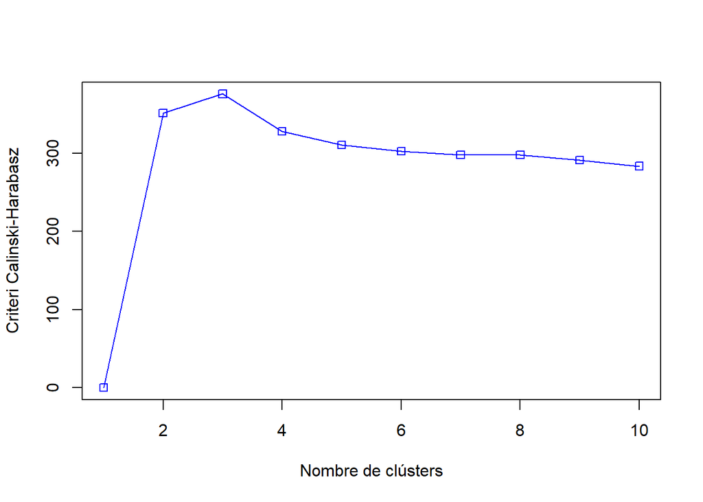

```r
plot(1:10,encaix_ch$crit,type="o",col="blue",pch=0,xlab="Nombre de clústers",ylab="Criteri Calinski-Harabasz")
```

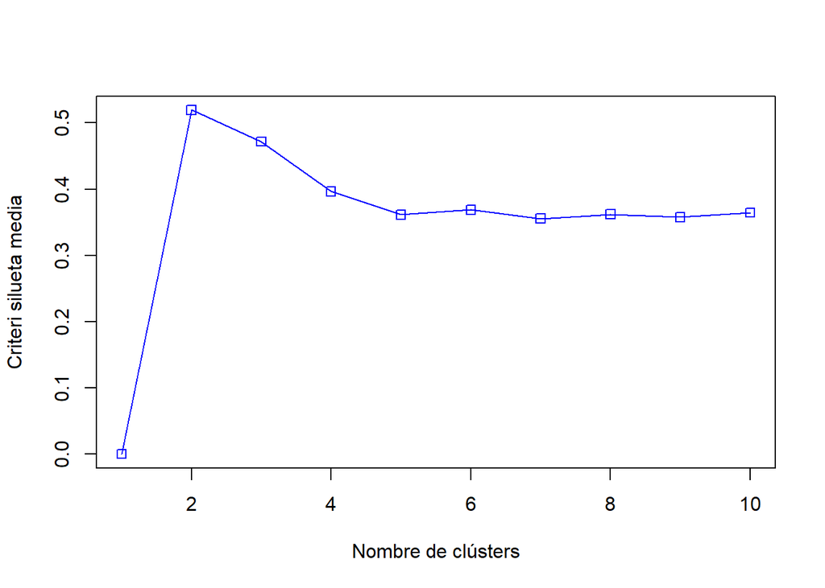

```r
plot(1:10,encaix_asw$crit,type="o",col="blue",pch=0,xlab="Nombre de clústers",ylab="Criteri silueta media")
```

Segons el criteri de la silueta mitja s’obtenen 2 clústers i amb el Calinski-Harabasz s’obtenen 3.

Veiem com es comporta el kmeans amb 3 classes comparant els camps dos a dos amb el valor real de classe.